# Analysis of *Stb15* transgenics screened with STB isolates

Amber N. Hafeez

## Data loading, removal of blank lines and data type conversion

```r
test1 <- read.csv("/Users/hafeeza/Documents/Stb15_Analyses/Transgenics/septoria_transgenics.csv", na.strings=c("*", "-","NA"), head=T)
test2 <- read.csv("/Users/hafeeza/Documents/Stb15_Analyses/Transgenics/stb15_transgenics_test2.csv", na.strings=c("*", "-","NA"), head=T)
rename <- read.csv("/Users/hafeeza/Documents/Stb15_Analyses/Transgenics/stb15_transgenics_renaming.csv", head=T)

# remove blank lines (these were included for experimental design purposes)
test1n <- test1[!(test1$Variety %in% c("Blank1", "Blank2", "Blank3", "Blank4")), ]
test2n <- test2[!(test2$Variety %in% c("Blank1", "Blank2", "Blank3", "Blank4", "Blank5", "Blank")), ]

sapply(test1n, class)
```

```
##     Isolate        Tray         Rep        Plot     Variety         d21
## "character"   "integer"   "integer"   "integer" "character"   "integer"
##         p21         d25         p25         d29         p29         d32
##   "integer"   "integer"   "integer"   "integer"   "integer"   "integer"
##         p32
##   "integer"
```

```r
test1n[,1:5] <- lapply(test1n[,1:5], factor)
test1n[,6:13] <- lapply(test1n[,6:13], as.numeric)

test2n[,1:5] <- lapply(test2n[,1:5], factor)
test2n[,6:13] <- lapply(test2n[,6:13], as.numeric)

sapply(test1n, class)
```

```
##   Isolate      Tray       Rep      Plot   Variety       d21       p21       d25
##  "factor"  "factor"  "factor"  "factor"  "factor" "numeric" "numeric" "numeric"
##       p25       d29       p29       d32       p32
## "numeric" "numeric" "numeric" "numeric" "numeric"
```

```r
head(test1n)
```

```
##    Isolate Tray Rep Plot      Variety d21 p21 d25 p25 d29 p29 d32 p32
## 2 IPO88004    1   1    2   21.8 CN4:2  15   0  60   0  60   0  75   0
## 5 IPO88004    1   1    5      Longbow   0   0   0   0   0   0  10   0
## 6 IPO88004    1   1    6   25.1 CN1:2  NA  NA  NA  NA  NA  NA  NA  NA
## 7 IPO88004    1   1    7   21.1 CN4:7  30   0  70   0  75   0  75   0
## 8 IPO88004    1   1    8   25.7 CN1:0  50   2  80   2  95   2 100   0
## 9 IPO88004    1   1    9 01.6 CN2-GRF  NA  NA  NA  NA  NA  NA  NA  NA
```

## Calculation of AUDPC

Function to calculate AUDPC for 4 scoring days.

```r
audpc <- function(df, day1, day2, day3, day4, insubset, ptype) {
(day2-day1)*(df[df$Isolate %in% insubset, paste0(ptype,day1)] + df[df$Isolate %in% insubset, paste0(ptype,day2)])/2 +
(day3-day2)*(df[df$Isolate %in% insubset, paste0(ptype,day2)] + df[df$Isolate %in% insubset, paste0(ptype,day3)])/2 +
(day4-day3)*(df[df$Isolate %in% insubset, paste0(ptype,day3)] + df[df$Isolate %in% insubset, paste0(ptype,day4)])/2
}
```

Calculations for each dataset. Scoring days were the same for both isolates so the same AUDPC calculation can be done.

```r
test1n[, "pAUDPC"] <- audpc(test1n, 21, 25, 29, 32, insubset=c("IPO88004", "IPO92006"), ptype="p")
test1n[, "dAUDPC"] <- audpc(test1n, 21, 25, 29, 32, insubset=c("IPO88004", "IPO92006"), ptype="d")

test2n[, "pAUDPC"] <- audpc(test2n, 17, 20, 24, 27, insubset=c("IPO88004", "IPO92006"), ptype="p")
test2n[, "dAUDPC"] <- audpc(test2n, 17, 20, 24, 27, insubset=c("IPO88004", "IPO92006"), ptype="d")
```

```r
max1 = (32-21)*100
max2 = (27-17)*100

test1n$pmax_pAUDPC <- (test1n$pAUDPC/max1)*100
test1n$pmax_dAUDPC <- (test1n$dAUDPC/max1)*100
test2n$pmax_pAUDPC <- (test2n$pAUDPC/max1)*100
test2n$pmax_dAUDPC <- (test2n$dAUDPC/max1)*100
```

Combine datasets

```r
test1n$Test <- "Test 1"
test2n$Test <- "Test 2"

test1.a <- test1n[, c(1:5,14:18)]
test2.a <- test2n[, c(1:5,14:18)]

# version with less columns
dat <- merge(test1.a, test2.a, all=T)

# version with all columns
alldat <- merge(test1n, test2n, all = T)
```

Perform logit transformation for each test with respective max scores and the smallest possible score for each dataset:

```r
min_score_test1 = (4*(0+1)/2)/4
min_score_test2 = (3*(0+1)/2)/4

dat[dat$Test=="Test 1", "lgt_pAUDPC"] <- log((dat[dat$Test=="Test 1", "pAUDPC"] + min_score_test1) / ((1100 + min_score_test1) - dat[dat$Test=="Test 1", "pAUDPC"]))
dat[dat$Test=="Test 2", "lgt_pAUDPC"] <- log((dat[dat$Test=="Test 2", "pAUDPC"] + min_score_test2) / ((1000 + min_score_test2) - dat[dat$Test=="Test 2", "pAUDPC"]))
```

Rename lines with updated transgenic line name codes. Also generate Genotype column to group lines by similar Stb15 status/genotype. This will be used for labelling later:

```r
dat <- merge(rename, dat, by="Variety")
dat$Variety <- dat$new_name
dat <- dat[,-2]

dat[dat$Variety %in% c("ChineseSpring"), "Genotype"] <- "Control -Stb15"
dat[dat$Variety %in% c("Arina", "Longbow"), "Genotype"] <- "Control +Stb15"
dat[dat$Variety %in% c("BastardII"), "Genotype"] <- "Resistant Control"
dat[dat$Variety %in% c("Fielder"), "Genotype"] <- "Wildtype Fielder"
dat[dat$Variety %in% c("Escape", "Null-2.1:0", "Null-1.1:0"), "Genotype"] <- "Negative Control Fielder"
dat[dat$Variety %in% c("GRF-5:4", "GRF-6:4"), "Genotype"] <- "Fielder +GRF -Stb15"
dat[dat$Variety %in% c("Stb15-1.2:2", "Stb15-2.2:2", "Stb15-2.3:2"), "Genotype"] <- "Fielder +Stb15 T0:1"
dat[dat$Variety %in% c("Stb15-4:4"), "Genotype"] <- "Fielder +Stb15 T0:2"
dat[dat$Variety %in% c("Stb15-3.1:2", "Stb15-3.2:5", "Stb15-3.3:7"), "Genotype"] <- "Fielder +Stb15 T0:4"

head(dat)
```

```
##   Variety  Isolate Tray Rep Plot pAUDPC dAUDPC pmax_pAUDPC pmax_dAUDPC   Test
## 1 GRF-5:4 IPO92006    6   1    6     45  665.0    4.090909    60.45455 Test 1
## 2 GRF-5:4 IPO88004    2   3   17     50 1000.0    4.545455    90.90909 Test 2
## 3 GRF-5:4 IPO88004    2   4   10      0  507.5    0.000000    46.13636 Test 1
## 4 GRF-5:4 IPO92006    7   4   11    275  900.0   25.000000    81.81818 Test 1
## 5 GRF-5:4 IPO92006    6  11   20     97  450.5    8.818182    40.95455 Test 2
## 6 GRF-5:4 IPO92006    6   2   19    270  790.0   24.545455    71.81818 Test 1
##   lgt_pAUDPC            Genotype
## 1  -3.144058 Fielder +GRF -Stb15
## 2  -2.937362 Fielder +GRF -Stb15
## 3  -7.696667 Fielder +GRF -Stb15
## 4  -1.097402 Fielder +GRF -Stb15
## 5  -2.227568 Fielder +GRF -Stb15
## 6  -1.121756 Fielder +GRF -Stb15
```

Load packages needed

```r
library(ggplot2)
library(ggsignif)
library(cowplot)
library(ggrepel)
library(pbkrtest)
library(Matrix)
library(lmerTest)
library(emmeans)
```

## Violin/box plots of raw data

These plots are split by isolate and coloured by test. The number of replicated for each isolate and test is shown in the table below:

```r
table(dat$Variety, dat$Test, dat$Isolate)
```

```
## , ,  = IPO88004
##
##
##                 Test 1 Test 2
##   Arina             10     10
##   BastardII         10     10
##   ChineseSpring     10     10
##   Escape            10     10
##   Fielder            9     10
##   GRF-5:4           10     10
##   GRF-6:4           10     10
##   Longbow           10     10
##   Null-1.1:0        10     10
##   Null-2.1:0        10     10
##   Stb15-1.2:2       10     10
##   Stb15-2.2:2       10     10
##   Stb15-2.3:2       10     10
##   Stb15-3.1:2       10     10
##   Stb15-3.2:5       10     10
##   Stb15-3.3:7       10      0
##   Stb15-4:4         10     10
##
## , ,  = IPO92006
##
##
##                 Test 1 Test 2
##   Arina              5      5
##   BastardII          5      6
##   ChineseSpring      5      5
##   Escape             5      5
##   Fielder            5      5
##   GRF-5:4            5      5
##   GRF-6:4            5      5
##   Longbow            5      5
##   Null-1.1:0         5      5
##   Null-2.1:0         5      5
##   Stb15-1.2:2        5      5
##   Stb15-2.2:2        5      5
##   Stb15-2.3:2        5      5
##   Stb15-3.1:2        5      5
##   Stb15-3.2:5        5      5
##   Stb15-3.3:7        5      0
##   Stb15-4:4          5      5
```

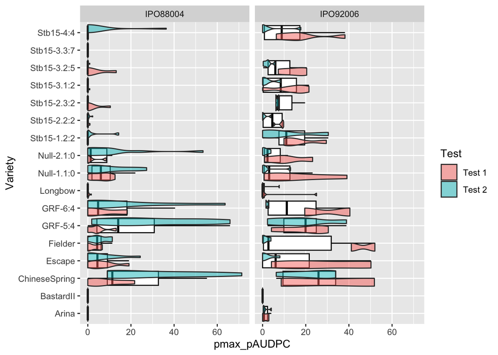

```r
ggplot(dat, aes(x=pmax_pAUDPC, y=Variety, fill=Test)) +
  geom_boxplot(width = 0.8, fill = "white", color = "black", outlier.shape = NA) +
  geom_violin(scale = "width", alpha=0.5) +
  facet_wrap(~Isolate)
```

Results appear to be more consistent between tests of IPO88004 than IPO92006. This could be due to differences in sample size (IPO88004 tests had more samples). In general, IPO88004 pycnidia scores seemed to be greater and more variable in Test 2, but resistant lines like Longbow, Bastard, Arina and the Stb15 transgenic lines had consistently low scores. Virulence on wildtype Fielder was lower than expected. Pycnidia scores were typically higher in the IPO92006 test.

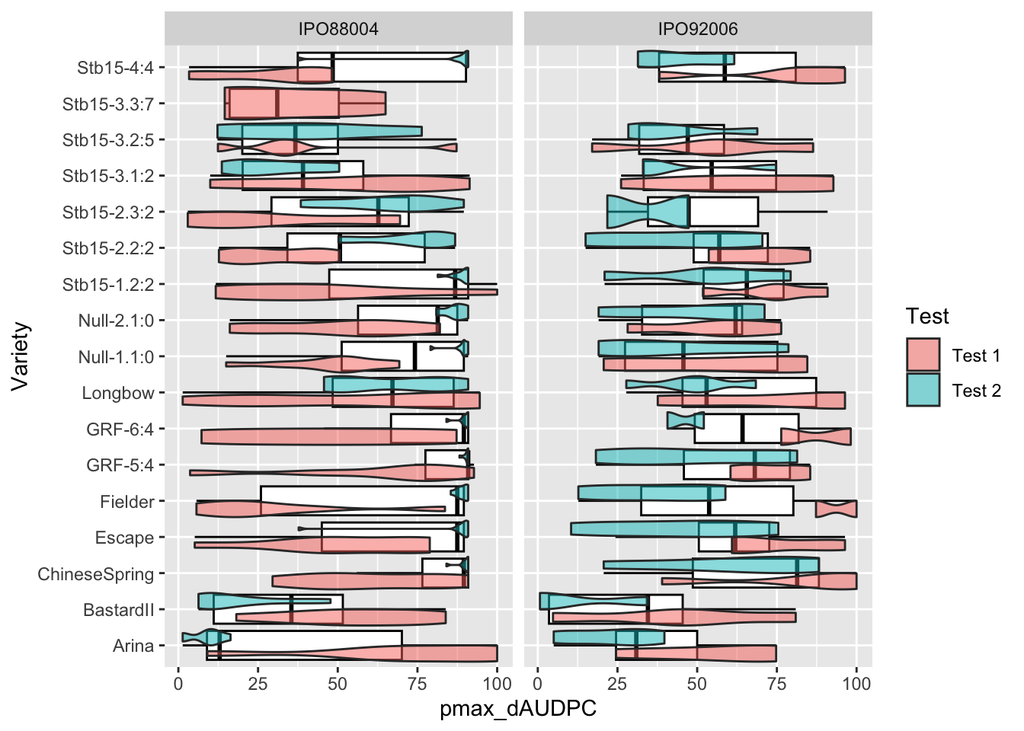

```r
ggplot(dat, aes(x=pmax_dAUDPC, y=Variety, fill=Test)) +
  geom_boxplot(width = 0.8, fill = "white", color = "black", outlier.shape = NA) +
  geom_violin(scale = "width", alpha=0.5) +
  facet_wrap(~Isolate)
```

Damage scores seem far more variable than pycnidia scores, especially in Test 1 of IPO88004.

## Statistical analysis

Several versions of the model are tested to check whether the random effects significantly improve ability of the model to explain variance. Model fitting was also tested separately in Genstat.

`lgt_pmod_full_v` has the most full version of the model, with the `Test*Isolate` and `Isolate*Variety` main effects and random effects of `Test:Tray`, `Test:Tray:Rep`, `Test:Variety` and `Test:Variety:Isolate`.

`lgt_pmod_v_lessv` has the random effect of `Test:Variety:Isolate` removed.

`lgt_pmod_v_nov` has both random effects which include Variety removed (`Test:Variety` and `Test:Variety:Isolate`).

```r
dat.nocn4.7 <- dat[!(dat$Variety=="Stb15-3.3:7"), ]

lgt_pmod_full_v <- lmer(lgt_pAUDPC ~ Test*Isolate + Isolate*Variety + (1|Test:Tray) + (1|Test:Tray:Rep) + (1|Test:Variety) + (1|Test:Variety:Isolate), data = dat.nocn4.7)
anova(lgt_pmod_full_v)
```

```
## Type III Analysis of Variance Table with Satterthwaite's method
##                 Sum Sq Mean Sq NumDF  DenDF F value    Pr(>F)
## Test              9.20   9.204     1 19.018  2.7857 0.1114858
## Isolate          89.37  89.373     1 16.247 27.0494 8.331e-05 ***
## Variety         322.51  21.501    15 16.373  6.5073 0.0002566 ***
## Test:Isolate     39.85  39.851     1 15.740 12.0612 0.0032037 **
## Isolate:Variety 135.69   9.046    15 14.612  2.7378 0.0313344 *
## ---
## Signif. codes:  0 '***' 0.001 '**' 0.01 '*' 0.05 '.' 0.1 ' ' 1
```

```r
# checking necessity of random effect of variety
lgt_pmod_v_lessv <- lmer(lgt_pAUDPC ~ Test*Isolate + Isolate*Variety + (1|Test:Tray) + (1|Test:Tray:Rep) + (1|Test:Variety), data = dat.nocn4.7)

lgt_pmod_v_nov <- lmer(lgt_pAUDPC ~ Test*Isolate + Isolate*Variety + (1|Test:Tray) + (1|Test:Tray:Rep), data = dat.nocn4.7)
```

Pairwise comparisons of the models will demonstrate whether there is an impact of removing the random effects:

```r
anova(lgt_pmod_v_nov, lgt_pmod_full_v, REML=F)
```

```
## refitting model(s) with ML (instead of REML)
```

```
## Data: dat.nocn4.7
## Models:
## lgt_pmod_v_nov: lgt_pAUDPC ~ Test * Isolate + Isolate * Variety + (1 | Test:Tray) + (1 | Test:Tray:Rep)
## lgt_pmod_full_v: lgt_pAUDPC ~ Test * Isolate + Isolate * Variety + (1 | Test:Tray) + (1 | Test:Tray:Rep) + (1 | Test:Variety) + (1 | Test:Variety:Isolate)
##                 npar    AIC    BIC  logLik deviance  Chisq Df Pr(>Chisq)
## lgt_pmod_v_nov    37 1736.7 1884.8 -831.37   1662.7
## lgt_pmod_full_v   39 1738.2 1894.3 -830.12   1660.2 2.5036  2      0.286
```

```r
anova(lgt_pmod_v_lessv, lgt_pmod_full_v, REML=F)
```

```
## refitting model(s) with ML (instead of REML)
```

```
## Data: dat.nocn4.7
## Models:
## lgt_pmod_v_lessv: lgt_pAUDPC ~ Test * Isolate + Isolate * Variety + (1 | Test:Tray) + (1 | Test:Tray:Rep) + (1 | Test:Variety)
## lgt_pmod_full_v: lgt_pAUDPC ~ Test * Isolate + Isolate * Variety + (1 | Test:Tray) + (1 | Test:Tray:Rep) + (1 | Test:Variety) + (1 | Test:Variety:Isolate)
##                  npar    AIC    BIC  logLik deviance Chisq Df Pr(>Chisq)
## lgt_pmod_v_lessv   38 1736.2 1888.3 -830.12   1660.2
## lgt_pmod_full_v    39 1738.2 1894.3 -830.12   1660.2     0  1          1
```

These results suggest that the random effect of variety does not significantly explain more residual variance. Therefore to simplify the model, we will move forward with `lgt_pmod_v_nov`.

Anova and summary tables for the final model:

```r
anova(lgt_pmod_v_nov)
```

```
## Type III Analysis of Variance Table with Satterthwaite's method
##                 Sum Sq Mean Sq NumDF  DenDF F value    Pr(>F)
## Test             15.71  15.710     1  12.48  4.2256  0.061356 .
## Isolate         121.40 121.399     1  13.14 32.6535 6.833e-05 ***
## Variety         937.79  62.520    15 348.64 16.8164 < 2.2e-16 ***
## Test:Isolate     56.12  56.125     1  12.48 15.0963  0.002018 **
## Isolate:Variety 255.70  17.047    15 348.64  4.5851 5.280e-08 ***
## ---
## Signif. codes:  0 '***' 0.001 '**' 0.01 '*' 0.05 '.' 0.1 ' ' 1
```

```r
summary(lgt_pmod_v_nov)
```

```
## Linear mixed model fit by REML. t-tests use Satterthwaite's method [
## lmerModLmerTest]
## Formula: lgt_pAUDPC ~ Test * Isolate + Isolate * Variety + (1 | Test:Tray) +
##     (1 | Test:Tray:Rep)
##    Data: dat.nocn4.7
##
## REML criterion at convergence: 1638.6
##
## Scaled residuals:
##     Min      1Q  Median      3Q     Max
## -2.8934 -0.4247 -0.0230  0.5650  3.3311
##
## Random effects:
##  Groups        Name        Variance Std.Dev.
##  Test:Tray:Rep (Intercept) 0.06336  0.2517
##  Test:Tray     (Intercept) 0.30042  0.5481
##  Residual                  3.71778  1.9282
## Number of obs: 404, groups:  Test:Tray:Rep, 30; Test:Tray, 16
##
## Fixed effects:
##                                       Estimate Std. Error        df t value
## (Intercept)                           -8.23201    0.57708 114.82384 -14.265
## TestTest 2                             0.67001    0.43626  11.35870   1.536
## IsolateIPO92006                        4.21928    0.94765 116.46930   4.452
## VarietyBastardII                       0.01954    0.68436 347.90331   0.029
## VarietyChineseSpring                   5.69779    0.68442 347.71795   8.325
## VarietyEscape                          3.71243    0.68475 350.45577   5.422
## VarietyFielder                         3.27049    0.69482 348.84150   4.707
## VarietyGRF-5:4                         5.54210    0.69630 350.09114   7.959
## VarietyGRF-6:4                         3.68450    0.70619 350.78418   5.217
## VarietyLongbow                         0.53455    0.65995 349.46310   0.810
## VarietyNull-1.1:0                      4.55131    0.67531 349.60002   6.740
## VarietyNull-2.1:0                      3.40718    0.66712 348.40673   5.107
## VarietyStb15-1.2:2                     1.17752    0.67573 349.12307   1.743
## VarietyStb15-2.2:2                     0.59416    0.66712 348.40673   0.891
## VarietyStb15-2.3:2                     0.34974    0.70573 347.71776   0.496
## VarietyStb15-3.1:2                     0.26518    0.69526 351.53908   0.381
## VarietyStb15-3.2:5                     0.59111    0.71992 353.09910   0.821
## VarietyStb15-4:4                       0.68148    0.66709 348.26308   1.022
## TestTest 2:IsolateIPO92006            -2.84546    0.73235  12.48416  -3.885
```

[output cut: 37 more lines]

```
## IsolateIPO92006:VarietyEscape         0.01932 *
## IsolateIPO92006:VarietyFielder        0.18687
## IsolateIPO92006:VarietyGRF-5:4        0.05685 .
## IsolateIPO92006:VarietyGRF-6:4        0.64291
## IsolateIPO92006:VarietyLongbow        0.16948
## IsolateIPO92006:VarietyNull-1.1:0     0.00368 **
## IsolateIPO92006:VarietyNull-2.1:0     0.03421 *
## IsolateIPO92006:VarietyStb15-1.2:2    0.30731
## IsolateIPO92006:VarietyStb15-2.2:2    0.90279
## IsolateIPO92006:VarietyStb15-2.3:2    0.02485 *
## IsolateIPO92006:VarietyStb15-3.1:2    0.47963
## IsolateIPO92006:VarietyStb15-3.2:5    0.17529
## IsolateIPO92006:VarietyStb15-4:4      0.41129
## ---
## Signif. codes:  0 '***' 0.001 '**' 0.01 '*' 0.05 '.' 0.1 ' ' 1
```

```
##
## Correlation matrix not shown by default, as p = 34 > 12.
## Use print(x, correlation=TRUE)  or
##     vcov(x)        if you need it
```

```r
rm(lgt_pmod_full_v, lgt_pmod_v_lessv)
```

Plot and check residuals vs fitted values, histogram of residuals and normal Q-Q plot:

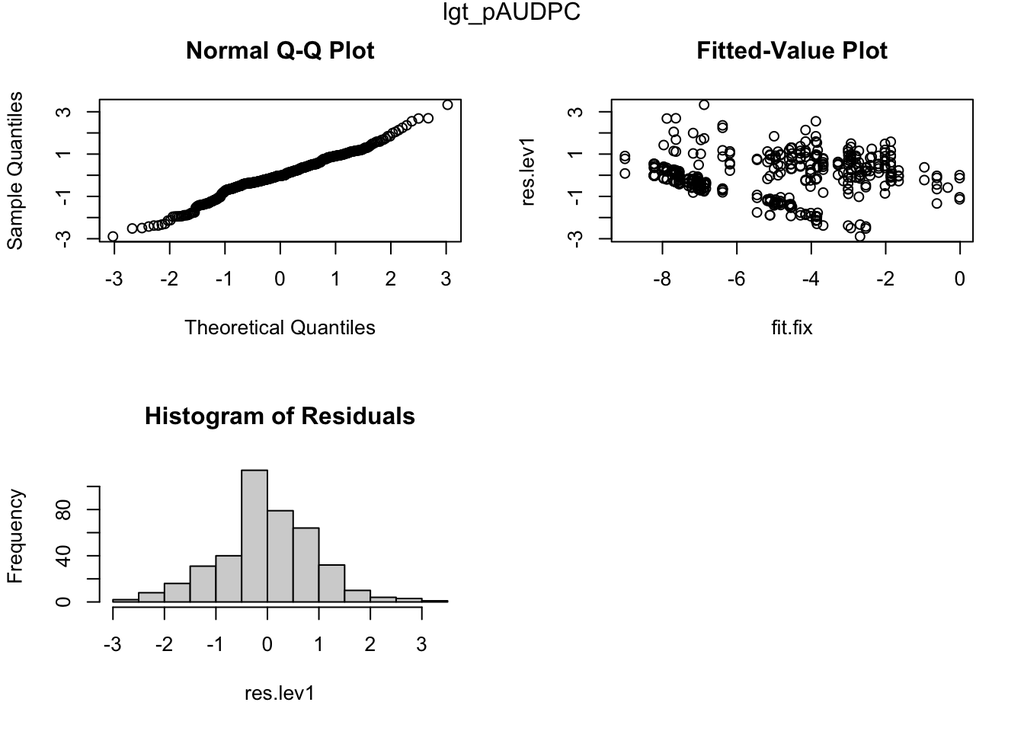

```r
res.lev1 <- resid(lgt_pmod_v_nov,scaled=T)
fit.fix <- predict(lgt_pmod_v_nov, re.form=~0)

par(mfrow=c(2,2))
qqnorm(res.lev1)
plot(res.lev1~fit.fix, main="Fitted-Value Plot")
hist(res.lev1, main = "Histogram of Residuals")
mtext("lgt_pAUDPC", side = 3, line = -1, outer = TRUE)
```

These plots indicate a good model fit.

### Fitting a model to damage data

```r
dmod_full_v <- lmer(pmax_dAUDPC ~ Test*Isolate + Isolate*Variety + (1|Test:Tray) + (1|Test:Tray:Rep) + (1|Test:Variety) + (1|Test:Variety:Isolate), data = dat.nocn4.7)
```

```
## boundary (singular) fit: see help('isSingular')
```

```r
anova(dmod_full_v)
```

```
## Type III Analysis of Variance Table with Satterthwaite's method
##                 Sum Sq Mean Sq NumDF  DenDF F value   Pr(>F)
## Test              84.4    84.4     1 30.542  0.2376 0.629431
## Isolate           56.1    56.1     1 30.817  0.1581 0.693685
## Variety         7469.4   498.0    15 33.321  1.4022 0.202967
## Test:Isolate    4683.4  4683.4     1 30.542 13.1880 0.001021 **
## Isolate:Variety 1416.2    94.4    15 33.321  0.2659 0.995751
## ---
## Signif. codes:  0 '***' 0.001 '**' 0.01 '*' 0.05 '.' 0.1 ' ' 1
```

```r
dmod_v_nov <- lmer(pmax_dAUDPC ~ Test*Isolate + Isolate*Variety + (1|Test:Tray) + (1|Test:Tray:Rep), data = dat.nocn4.7)
dmod_v_lessv1 <- lmer(pmax_dAUDPC ~ Test*Isolate + Isolate*Variety + (1|Test:Tray) + (1|Test:Tray:Rep) + (1|Test:Variety), data = dat.nocn4.7)
dmod_v_lessv2 <- lmer(pmax_dAUDPC ~ Test*Isolate + Isolate*Variety + (1|Test:Tray) + (1|Test:Tray:Rep) + (1|Test:Variety:Isolate), data = dat.nocn4.7)

# comparisons
anova(dmod_v_nov, dmod_full_v, REML=F)
```

```
## refitting model(s) with ML (instead of REML)
```

```
## Data: dat.nocn4.7
## Models:
## dmod_v_nov: pmax_dAUDPC ~ Test * Isolate + Isolate * Variety + (1 | Test:Tray) + (1 | Test:Tray:Rep)
## dmod_full_v: pmax_dAUDPC ~ Test * Isolate + Isolate * Variety + (1 | Test:Tray) + (1 | Test:Tray:Rep) + (1 | Test:Variety) + (1 | Test:Variety:Isolate)
##             npar    AIC    BIC  logLik deviance  Chisq Df Pr(>Chisq)
## dmod_v_nov    37 3759.3 3907.5 -1842.7   3685.3
## dmod_full_v   39 3702.4 3858.6 -1812.2   3624.4 60.918  2  5.914e-14 ***
## ---
## Signif. codes:  0 '***' 0.001 '**' 0.01 '*' 0.05 '.' 0.1 ' ' 1
```

```r
anova(dmod_v_lessv1, dmod_full_v, REML=F)
```

```
## refitting model(s) with ML (instead of REML)
```

```
## Data: dat.nocn4.7
## Models:
## dmod_v_lessv1: pmax_dAUDPC ~ Test * Isolate + Isolate * Variety + (1 | Test:Tray) + (1 | Test:Tray:Rep) + (1 | Test:Variety)
## dmod_full_v: pmax_dAUDPC ~ Test * Isolate + Isolate * Variety + (1 | Test:Tray) + (1 | Test:Tray:Rep) + (1 | Test:Variety) + (1 | Test:Variety:Isolate)
##               npar    AIC    BIC  logLik deviance  Chisq Df Pr(>Chisq)
## dmod_v_lessv1   38 3722.0 3874.2 -1823.0   3646.0
## dmod_full_v     39 3702.4 3858.6 -1812.2   3624.4 21.595  1  3.368e-06 ***
## ---
## Signif. codes:  0 '***' 0.001 '**' 0.01 '*' 0.05 '.' 0.1 ' ' 1
```

```r
anova(dmod_v_lessv2, dmod_full_v, REML=F)
```

```
## refitting model(s) with ML (instead of REML)
```

```
## Data: dat.nocn4.7
## Models:
## dmod_v_lessv2: pmax_dAUDPC ~ Test * Isolate + Isolate * Variety + (1 | Test:Tray) + (1 | Test:Tray:Rep) + (1 | Test:Variety:Isolate)
## dmod_full_v: pmax_dAUDPC ~ Test * Isolate + Isolate * Variety + (1 | Test:Tray) + (1 | Test:Tray:Rep) + (1 | Test:Variety) + (1 | Test:Variety:Isolate)
##               npar    AIC    BIC  logLik deviance Chisq Df Pr(>Chisq)
## dmod_v_lessv2   38 3700.4 3852.6 -1812.2   3624.4
## dmod_full_v     39 3702.4 3858.6 -1812.2   3624.4 1e-04  1     0.9905
```

```r
anova(dmod_v_lessv1)
```

```
## Type III Analysis of Variance Table with Satterthwaite's method
##                 Sum Sq Mean Sq NumDF  DenDF F value    Pr(>F)
## Test              31.6    31.6     1  23.43  0.0759 0.7853162
## Isolate          167.4   167.4     1  12.95  0.4018 0.5372158
## Variety         6002.7   400.2    15  15.64  0.9606 0.5294046
## Test:Isolate    8797.2  8797.2     1  12.59 21.1169 0.0005443 ***
## Isolate:Variety 7614.8   507.7    15 331.82  1.2186 0.2554550
## ---
## Signif. codes:  0 '***' 0.001 '**' 0.01 '*' 0.05 '.' 0.1 ' ' 1
```

```r
summary(dmod_v_lessv1)
```

```
## Linear mixed model fit by REML. t-tests use Satterthwaite's method [
## lmerModLmerTest]
## Formula: pmax_dAUDPC ~ Test * Isolate + Isolate * Variety + (1 | Test:Tray) +
##     (1 | Test:Tray:Rep) + (1 | Test:Variety)
##    Data: dat.nocn4.7
##
## REML criterion at convergence: 3431.9
##
## Scaled residuals:
##     Min      1Q  Median      3Q     Max
## -3.0655 -0.5851  0.1445  0.5022  2.7482
##
## Random effects:
##  Groups        Name        Variance Std.Dev.
##  Test:Variety  (Intercept) 236.49   15.378
##  Test:Tray:Rep (Intercept)  11.12    3.334
##  Test:Tray     (Intercept)  66.25    8.139
##  Residual                  416.60   20.411
## Number of obs: 405, groups:  Test:Variety, 32; Test:Tray:Rep, 30; Test:Tray, 16
##
## Fixed effects:
##                                      Estimate Std. Error      df t value
## (Intercept)                            28.827     13.041  20.472   2.211
## TestTest 2                             20.705      8.051  22.887   2.572
## IsolateIPO92006                        23.609     10.935  69.605   2.159
## VarietyBastardII                       -2.454     17.004  17.046  -0.144
## VarietyChineseSpring                   36.341     17.016  17.089   2.136
## VarietyEscape                          30.498     17.018  17.097   1.792
## VarietyFielder                         22.522     17.018  17.094   1.323
## VarietyGRF-5:4                         38.512     17.088  17.369   2.254
## VarietyGRF-6:4                         29.640     17.128  17.527   1.731
## VarietyLongbow                         23.025     16.894  16.613   1.363
## VarietyNull-1.1:0                      28.951     16.962  16.881   1.707
## VarietyNull-2.1:0                      29.450     16.927  16.741   1.740
## VarietyStb15-1.2:2                     28.899     16.970  16.909   1.703
## VarietyStb15-2.2:2                     12.845     16.927  16.740   0.759
## VarietyStb15-2.3:2                     10.120     17.125  17.516   0.591
## VarietyStb15-3.1:2                      3.545     17.053  17.246   0.208
## VarietyStb15-3.2:5                     -1.174     17.210  17.855  -0.068
## VarietyStb15-4:4                       19.062     16.927  16.740   1.126
```

[output cut: 38 more lines]

```
## IsolateIPO92006:VarietyEscape        0.318808
## IsolateIPO92006:VarietyFielder       0.621947
## IsolateIPO92006:VarietyGRF-5:4       0.133770
## IsolateIPO92006:VarietyGRF-6:4       0.836940
## IsolateIPO92006:VarietyLongbow       0.900307
## IsolateIPO92006:VarietyNull-1.1:0    0.101097
## IsolateIPO92006:VarietyNull-2.1:0    0.126676
## IsolateIPO92006:VarietyStb15-1.2:2   0.494952
## IsolateIPO92006:VarietyStb15-2.2:2   0.842613
## IsolateIPO92006:VarietyStb15-2.3:2   0.476778
## IsolateIPO92006:VarietyStb15-3.1:2   0.544488
## IsolateIPO92006:VarietyStb15-3.2:5   0.451672
## IsolateIPO92006:VarietyStb15-4:4     0.899169
## ---
## Signif. codes:  0 '***' 0.001 '**' 0.01 '*' 0.05 '.' 0.1 ' ' 1
```

```
##
## Correlation matrix not shown by default, as p = 34 > 12.
## Use print(x, correlation=TRUE)  or
##     vcov(x)        if you need it
```

```r
rm(dmod_full_v, dmod_v_lessv2, dmod_v_nov)
```

Plot and check residuals vs fitted values, histogram of residuals and normal Q-Q plot:

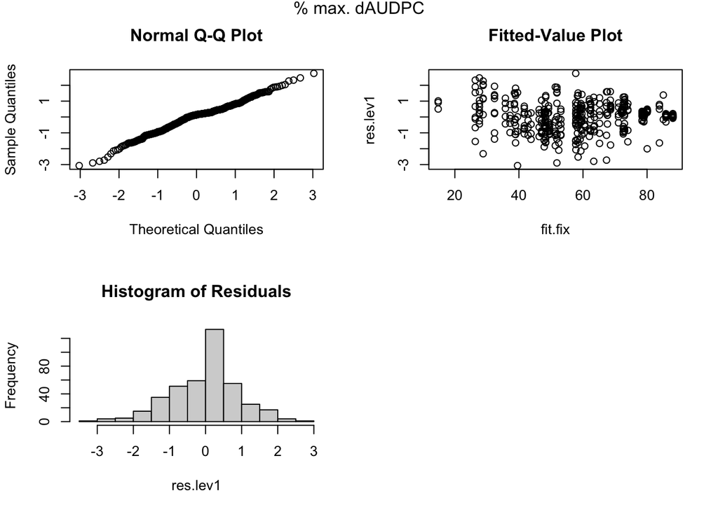

```r
res.lev1 <- resid(dmod_v_lessv1,scaled=T)
fit.fix <- predict(dmod_v_lessv1, re.form=~0)

par(mfrow=c(2,2))
qqnorm(res.lev1)
plot(res.lev1~fit.fix, main="Fitted-Value Plot")
hist(res.lev1, main = "Histogram of Residuals")
mtext("% max. dAUDPC", side = 3, line = -1, outer = TRUE)
```

The plots indicate a good model fit.

## Estimated marginal means

Looking at pairwise comparisons between each genotype group averaged over Test and separated by Isolate. Used methods as detailed in this [cran.r guide to emmeans comparisons](https://cran.r-project.org/web/packages/emmeans/vignettes/comparisons.html#:~:text=all%20vignette%20topics-,Pairwise%20comparisons,then%20compare%20the%20sources%20pairwise.)

Red arrows represent pairwise comparisons whilst the blue/purple boxes represent confidence intervals. Where they overlap, the groups are not significantly different from each other.

For pycnidia:

```r
emlgtp.v <- emmeans(lgt_pmod_v_nov, c("Variety"), by=c("Isolate"))
pairs(emlgtp.v)
```

```
## Isolate = IPO88004:
##  contrast                      estimate    SE  df t.ratio p.value
##  Arina - BastardII             -0.01954 0.685 348  -0.029  1.0000
##  Arina - ChineseSpring         -5.69779 0.685 348  -8.318  <.0001
##  Arina - Escape                -3.71243 0.686 351  -5.415  <.0001
##  Arina - Fielder               -3.27049 0.696 349  -4.702  0.0004
##  Arina - (GRF-5:4)             -5.54210 0.697 350  -7.949  <.0001
##  Arina - (GRF-6:4)             -3.68450 0.707 351  -5.210  <.0001
##  Arina - Longbow               -0.53455 0.661 350  -0.809  1.0000
##  Arina - (Null-1.1:0)          -4.55131 0.676 350  -6.731  <.0001
##  Arina - (Null-2.1:0)          -3.40718 0.668 349  -5.103  0.0001
##  Arina - (Stb15-1.2:2)         -1.17752 0.676 349  -1.741  0.9344
##  Arina - (Stb15-2.2:2)         -0.59416 0.668 349  -0.890  1.0000
##  Arina - (Stb15-2.3:2)         -0.34974 0.706 348  -0.495  1.0000
##  Arina - (Stb15-3.1:2)         -0.26518 0.696 352  -0.381  1.0000
##  Arina - (Stb15-3.2:5)         -0.59111 0.721 353  -0.820  1.0000
##  Arina - (Stb15-4:4)           -0.68148 0.668 348  -1.021  0.9997
##  BastardII - ChineseSpring     -5.67825 0.662 346  -8.573  <.0001
##  BastardII - Escape            -3.69289 0.663 349  -5.571  <.0001
##  BastardII - Fielder           -3.25095 0.672 345  -4.837  0.0002
##  BastardII - (GRF-5:4)         -5.52256 0.675 348  -8.186  <.0001
##  BastardII - (GRF-6:4)         -3.66496 0.687 349  -5.338  <.0001
##  BastardII - Longbow           -0.51500 0.637 348  -0.808  1.0000
##  BastardII - (Null-1.1:0)      -4.53177 0.654 347  -6.935  <.0001
##  BastardII - (Null-2.1:0)      -3.38763 0.645 347  -5.255  <.0001
##  BastardII - (Stb15-1.2:2)     -1.15798 0.654 347  -1.772  0.9247
##  BastardII - (Stb15-2.2:2)     -0.57461 0.645 347  -0.891  1.0000
##  BastardII - (Stb15-2.3:2)     -0.33019 0.685 348  -0.482  1.0000
##  BastardII - (Stb15-3.1:2)     -0.24564 0.674 349  -0.364  1.0000
##  BastardII - (Stb15-3.2:5)     -0.57157 0.698 350  -0.819  1.0000
##  BastardII - (Stb15-4:4)       -0.66193 0.645 347  -1.027  0.9997
##  ChineseSpring - Escape         1.98536 0.663 349   2.995  0.1764
##  ChineseSpring - Fielder        2.42730 0.673 347   3.606  0.0305
##  ChineseSpring - (GRF-5:4)      0.15569 0.675 348   0.231  1.0000
##  ChineseSpring - (GRF-6:4)      2.01329 0.687 349   2.930  0.2057
##  ChineseSpring - Longbow        5.16324 0.638 347   8.093  <.0001
##  ChineseSpring - (Null-1.1:0)   1.14648 0.654 346   1.753  0.9307
##  ChineseSpring - (Null-2.1:0)   2.29061 0.645 346   3.553  0.0363
##  ChineseSpring - (Stb15-1.2:2)  4.52027 0.654 347   6.911  <.0001
##  ChineseSpring - (Stb15-2.2:2)  5.10363 0.645 346   7.916  <.0001
```

[output cut: 194 more lines]

```
##  (Stb15-1.2:2) - (Stb15-4:4)    0.76531 0.917 347   0.835  1.0000
##  (Stb15-2.2:2) - (Stb15-2.3:2) -2.95071 1.288 355  -2.291  0.6309
##  (Stb15-2.2:2) - (Stb15-3.1:2) -0.34632 0.887 346  -0.390  1.0000
##  (Stb15-2.2:2) - (Stb15-3.2:5) -1.43686 0.887 346  -1.620  0.9639
##  (Stb15-2.2:2) - (Stb15-4:4)   -0.86452 0.862 344  -1.003  0.9998
##  (Stb15-2.3:2) - (Stb15-3.1:2)  2.60439 1.309 357   1.989  0.8300
##  (Stb15-2.3:2) - (Stb15-3.2:5)  1.51385 1.302 355   1.162  0.9988
##  (Stb15-2.3:2) - (Stb15-4:4)    2.08619 1.288 355   1.620  0.9640
##  (Stb15-3.1:2) - (Stb15-3.2:5) -1.09054 0.912 348  -1.196  0.9983
##  (Stb15-3.1:2) - (Stb15-4:4)   -0.51820 0.887 346  -0.584  1.0000
##  (Stb15-3.2:5) - (Stb15-4:4)    0.57234 0.887 346   0.645  1.0000
##
## Results are averaged over the levels of: Test
## Degrees-of-freedom method: kenward-roger
## P value adjustment: tukey method for comparing a family of 16 estimates
```

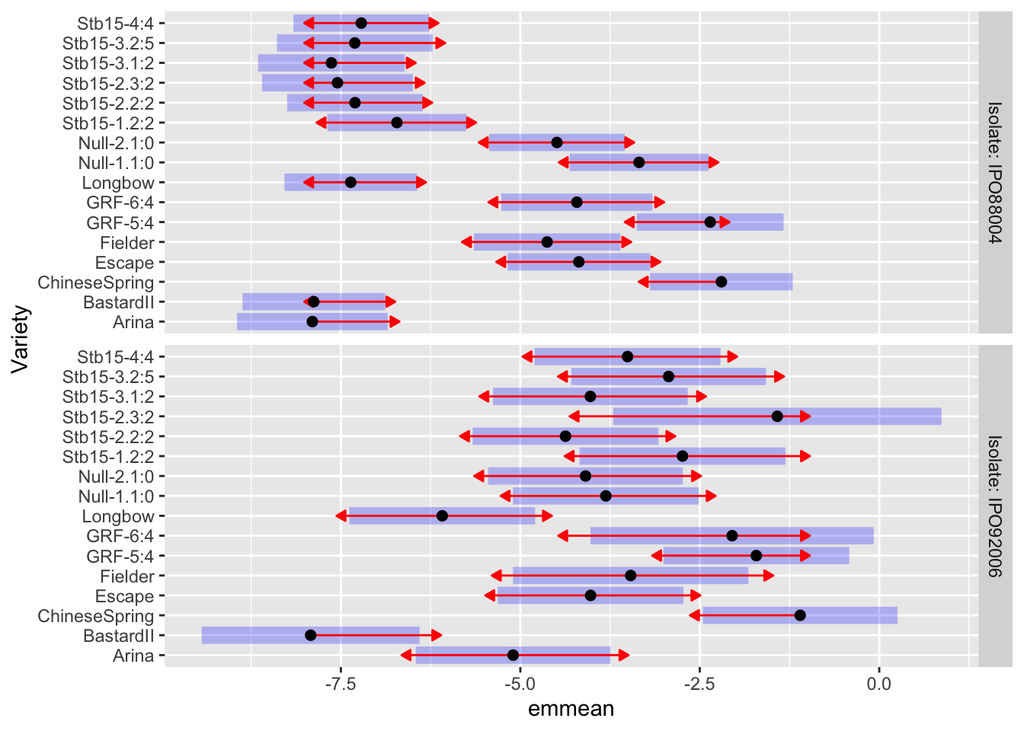

```r
plot(emlgtp.v, comparisons=T, )
```

```r
dev.off()
```

There is clear separation of the means of the transgenic lines carrying *Stb15* from Fielder, the nulls and GRF construct-containing transgenic controls. There is one exception which is that Stb15-1.2:2 slightly overlaps with Fielder. This effect is isolate-specific, as demonstrated by fact that there is no significant difference between transgenics carrying *Stb15* and Fielder (and other lines that do not carry the gene) when looking at IPO92006 pycnidia scores.

For damage:

```r
empmd.v <- emmeans(dmod_v_lessv1, c("Variety"), by=c("Isolate"))
pairs(empmd.v)
```

```
## Isolate = IPO88004:
##  contrast                      estimate   SE   df t.ratio p.value
##  Arina - BastardII               2.4540 17.0 17.1   0.144  1.0000
##  Arina - ChineseSpring         -36.3413 17.0 17.1  -2.135  0.7247
##  Arina - Escape                -30.4982 17.0 17.1  -1.792  0.8895
##  Arina - Fielder               -22.5225 17.0 17.1  -1.323  0.9885
##  Arina - (GRF-5:4)             -38.5119 17.1 17.4  -2.253  0.6566
##  Arina - (GRF-6:4)             -29.6398 17.1 17.6  -1.730  0.9117
##  Arina - Longbow               -23.0249 16.9 16.6  -1.363  0.9849
##  Arina - (Null-1.1:0)          -28.9512 17.0 16.9  -1.706  0.9183
##  Arina - (Null-2.1:0)          -29.4496 16.9 16.8  -1.740  0.9074
##  Arina - (Stb15-1.2:2)         -28.8991 17.0 16.9  -1.703  0.9196
##  Arina - (Stb15-2.2:2)         -12.8446 16.9 16.8  -0.759  1.0000
##  Arina - (Stb15-2.3:2)         -10.1196 17.1 17.6  -0.591  1.0000
##  Arina - (Stb15-3.1:2)          -3.5450 17.1 17.3  -0.208  1.0000
##  Arina - (Stb15-3.2:5)           1.1736 17.2 17.9   0.068  1.0000
##  Arina - (Stb15-4:4)           -19.0624 16.9 16.8  -1.126  0.9974
##  BastardII - ChineseSpring     -38.7953 16.9 16.7  -2.293  0.6328
##  BastardII - Escape            -32.9523 16.9 16.7  -1.948  0.8225
##  BastardII - Fielder           -24.9765 16.9 16.7  -1.476  0.9710
##  BastardII - (GRF-5:4)         -40.9659 17.0 17.0  -2.411  0.5626
##  BastardII - (GRF-6:4)         -32.0939 17.0 17.2  -1.884  0.8524
##  BastardII - Longbow           -25.4789 16.8 16.2  -1.517  0.9637
##  BastardII - (Null-1.1:0)      -31.4052 16.9 16.5  -1.862  0.8606
##  BastardII - (Null-2.1:0)      -31.9037 16.8 16.4  -1.896  0.8458
##  BastardII - (Stb15-1.2:2)     -31.3531 16.9 16.5  -1.858  0.8622
##  BastardII - (Stb15-2.2:2)     -15.2986 16.8 16.4  -0.909  0.9997
##  BastardII - (Stb15-2.3:2)     -12.5736 17.0 17.1  -0.738  1.0000
##  BastardII - (Stb15-3.1:2)      -5.9990 17.0 16.9  -0.354  1.0000
##  BastardII - (Stb15-3.2:5)      -1.2804 17.1 17.4  -0.075  1.0000
##  BastardII - (Stb15-4:4)       -21.5164 16.8 16.4  -1.279  0.9913
##  ChineseSpring - Escape          5.8430 16.9 16.8   0.345  1.0000
##  ChineseSpring - Fielder        13.8188 16.9 16.8   0.816  0.9999
##  ChineseSpring - (GRF-5:4)      -2.1706 17.0 17.1  -0.128  1.0000
##  ChineseSpring - (GRF-6:4)       6.7014 17.1 17.2   0.393  1.0000
##  ChineseSpring - Longbow        13.3164 16.8 16.3   0.792  0.9999
##  ChineseSpring - (Null-1.1:0)    7.3900 16.9 16.6   0.438  1.0000
##  ChineseSpring - (Null-2.1:0)    6.8916 16.8 16.4   0.409  1.0000
##  ChineseSpring - (Stb15-1.2:2)   7.4422 16.9 16.6   0.441  1.0000
##  ChineseSpring - (Stb15-2.2:2)  23.4966 16.8 16.4   1.395  0.9814
```

[output cut: 194 more lines]

```
##  (Stb15-1.2:2) - (Stb15-4:4)    -0.0249 18.2 22.3  -0.001  1.0000
##  (Stb15-2.2:2) - (Stb15-2.3:2)  -6.1123 20.6 36.2  -0.296  1.0000
##  (Stb15-2.2:2) - (Stb15-3.1:2)   4.2668 18.0 21.5   0.237  1.0000
##  (Stb15-2.2:2) - (Stb15-3.2:5)   7.0780 18.0 21.5   0.393  1.0000
##  (Stb15-2.2:2) - (Stb15-4:4)    -5.3727 17.9 20.9  -0.300  1.0000
##  (Stb15-2.3:2) - (Stb15-3.1:2)  10.3791 20.8 37.2   0.499  1.0000
##  (Stb15-2.3:2) - (Stb15-3.2:5)  13.1904 20.7 36.9   0.636  1.0000
##  (Stb15-2.3:2) - (Stb15-4:4)     0.7396 20.6 36.2   0.036  1.0000
##  (Stb15-3.1:2) - (Stb15-3.2:5)   2.8112 18.2 22.2   0.155  1.0000
##  (Stb15-3.1:2) - (Stb15-4:4)    -9.6395 18.0 21.5  -0.535  1.0000
##  (Stb15-3.2:5) - (Stb15-4:4)   -12.4507 18.0 21.5  -0.691  1.0000
##
## Results are averaged over the levels of: Test
## Degrees-of-freedom method: kenward-roger
## P value adjustment: tukey method for comparing a family of 16 estimates
```

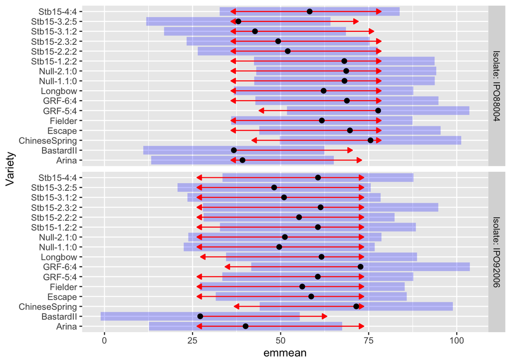

```r
plot(empmd.v, comparisons=T, )
```

```r
dev.off()
```

Although some resistant leaf samples were observed to have low damage scores, this was not consistent enough across reps to be statistically significant.Pairwise comparisons showed no differences between groups. This could be because damage scores are more likely to be affected by environmental stressors leading to high residual variance that could unfortunately not be sufficiently explained by our model.

Extracting line means:

```r
emm.pmod <- emmeans::emmeans(lgt_pmod_v_nov, specs="Isolate", by="Variety"); est.pmod <- as.data.frame(emm.pmod)

emm.dmod <- emmeans::emmeans(dmod_v_lessv1, specs="Isolate", by="Variety"); est.dmod <- as.data.frame(emm.dmod)
```

## Plots of estimated means

Prepare the data for plotting. Separate columns are needed for IPO88004 and IPO92006 results and the genotype group information needs to be added.

```r
palette9 = c("#000000", "#737372", "#D55E00", "#56B4E9", "#009E73", "#0072B2", "#CC79A7", "#F0E442", "#E69F00")

est.lgtp.IPO92006 <- est.pmod[est.pmod$Isolate=="IPO92006", ]
colnames(est.lgtp.IPO92006)[3] <- "lgt_pAUDPC_IPO92006"
est.lgtp.IPO88004 <- est.pmod[est.pmod$Isolate=="IPO88004", ]
colnames(est.lgtp.IPO88004)[3] <- "lgt_pAUDPC_IPO88004"
ests.by.isolate.p <- merge(est.lgtp.IPO88004, est.lgtp.IPO92006, by="Variety")

est.dam.IPO92006 <- est.dmod[est.dmod$Isolate=="IPO92006", ]
colnames(est.dam.IPO92006)[3] <- "pmax_dAUDPC_IPO92006"
est.dam.IPO88004 <- est.dmod[est.dmod$Isolate=="IPO88004", ]
colnames(est.dam.IPO88004)[3] <- "pmax_dAUDPC_IPO88004"
ests.by.isolate.d <- merge(est.dam.IPO88004, est.dam.IPO92006, by="Variety")

groups <- unique(dat[,c("Variety", "Genotype")])

ests.by.isolate.p <- merge(ests.by.isolate.p, groups, by="Variety")
ests.by.isolate.d <- merge(ests.by.isolate.d, groups, by="Variety")
ests.by.isolate <- merge(ests.by.isolate.p[,c("Variety","Genotype", "lgt_pAUDPC_IPO92006","lgt_pAUDPC_IPO88004")], ests.by.isolate.d[,c("Variety", "pmax_dAUDPC_IPO92006", "pmax_dAUDPC_IPO88004")], by="Variety")
```

Plot of mean logit pAUDPC and % max. damage scores vs IPO88004 plotted against each other:

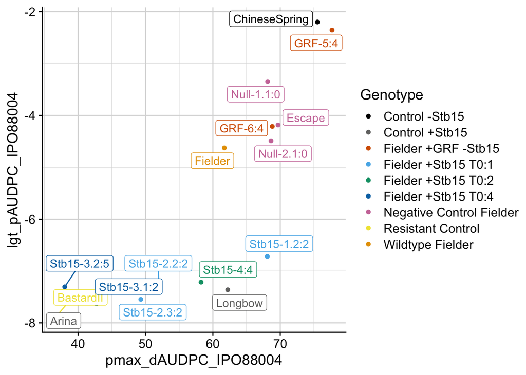

```r
ggplot(ests.by.isolate, aes(y=lgt_pAUDPC_IPO88004, x=pmax_dAUDPC_IPO88004, color=Genotype)) +
  geom_point() +
  scale_color_manual(values=palette9) +
  geom_label_repel(data = ests.by.isolate, aes(label=Variety, color=Genotype), fill="white", show.legend = FALSE) +
  theme_half_open() +
  background_grid(minor = "xy")
```

It is clear that the transgenic lines with Stb15 cluster with the resistant controls whilst the control lines containing GRF-GIF and the nulls cluster with the susceptible lines including Fielder and Chinese Spring. It can clearly be observed that the amount of leaf damage varied in lines considered resistant due to their pycnidia score. Transgenics in the Fielder +Stb15 T0:4 family were the most green, similarly to resistant controls Bastard II and Arina.

Plot of mean logit pAUDPC scores vs each isolate plotted against each other:

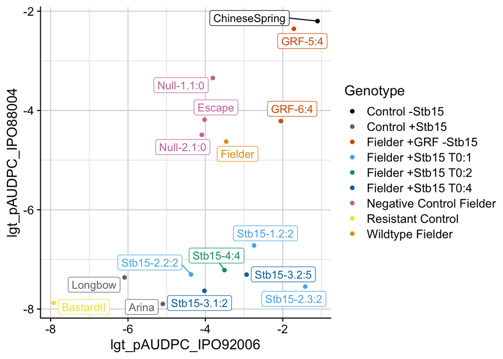

```r
ggplot(ests.by.isolate, aes(y=lgt_pAUDPC_IPO88004, x=lgt_pAUDPC_IPO92006, color=Genotype)) +
  geom_point() +
  scale_color_manual(values=palette9) +
  geom_label_repel(data = ests.by.isolate, aes(label=Variety, color=Genotype), fill="white", show.legend = FALSE) +
  theme_half_open() +
  background_grid(minor = "xy")
```

This demonstrates that low pycnidia scores of the *Stb15* transgenics in response to IPO88004 were isolate-specific and the gene does not confer resistance to the control virulent isolate IPO92006.

Plot of mean % max. dAUDPC scores vs each isolate plotted against each other:

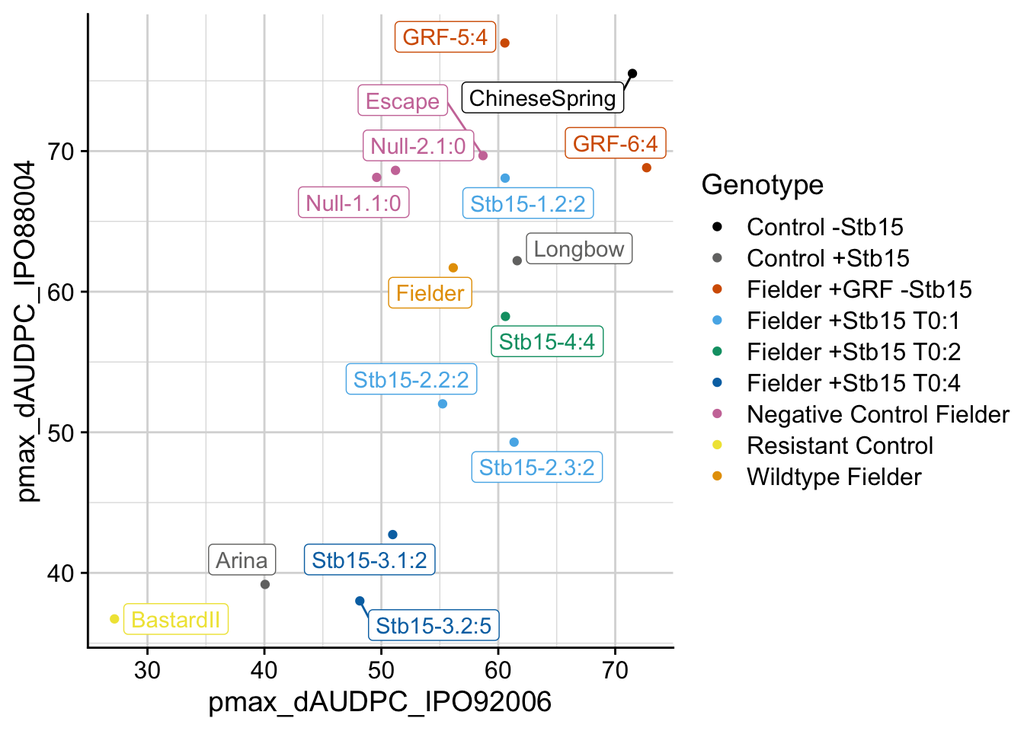

```r
ggplot(ests.by.isolate.d, aes(y=pmax_dAUDPC_IPO88004, x=pmax_dAUDPC_IPO92006, color=Genotype)) +
  geom_point() +
  scale_color_manual(values=palette9) +
  geom_label_repel(data = ests.by.isolate.d, aes(label=Variety, color=Genotype), fill="white", show.legend = FALSE) +
  theme_half_open() +
  background_grid(minor = "xy")
```

Transgenics in the Fielder +Stb15 T0:4 family seemed to show some isolate-specificity in their damage scores. However, this was not significant according to the pairwise comparisons.